# Introduction to TreeSummarizedExperiment

## 2.6 Changing the tree

The current tree can be replaced by a new one using `changeTree`. If the hierarchical information is available as a `data.frame` with each column representing a taxonomic level (e.g., *row_data*), we provide `toTree` to convert it into a `phylo` object.

```r
# The toy taxonomic table
(taxa <- rowData(both_tse))
```

```
## DataFrame with 6 rows and 4 columns
##             Kingdom      Phylum       Class         OTU
##         <character> <character> <character> <character>
## entity1           A          B1          C1          D1
## entity2           A          B1          C1          D2
## entity3           A          B2          C2          D3
## entity4           A          B2          C2          D4
## entity5           A          B2          C3          D5
## entity6           A          B2          C3          D6
```

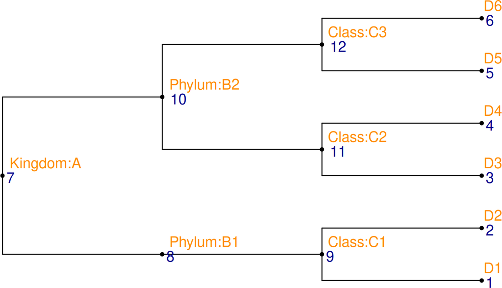

Figure 4: The structure of the taxonomic tree that is generated from the taxonomic table

```r
# convert it to a phylo tree
taxa_tree <- toTree(data = taxa)

# Viz the new tree
ggtree(taxa_tree)+
    geom_text2(aes(label = node), color = "darkblue",
               hjust = -0.5, vjust = 0.7, size = 5.5) +
    geom_text2(aes(label = label), color = "darkorange",
               hjust = -0.1, vjust = -0.7, size = 5.5) +
    geom_point2()
```

A mapping to match nodes of the two trees is required if nodes are labeled differently.

```r
taxa_tse <- changeTree(x = both_tse, rowTree = taxa_tree,
                       rowNodeLab = taxa[["OTU"]])

taxa_tse
```

```
## class: TreeSummarizedExperiment
## dim: 6 4
## metadata(0):
## assays(1): Count
## rownames(6): entity1 entity2 ... entity5 entity6
## rowData names(4): Kingdom Phylum Class OTU
## colnames(4): sample1 sample2 sample3 sample4
## colData names(2): gg group
## reducedDimNames(0):
## mainExpName: NULL
## altExpNames(0):
## rowLinks: a LinkDataFrame (6 rows)
## rowTree: 1 phylo tree(s) (6 leaves)
## colLinks: a LinkDataFrame (4 rows)
## colTree: 1 phylo tree(s) (4 leaves)
## referenceSeq: a DNAStringSet (6 sequences)
```

```r
rowLinks(taxa_tse)
```

```
## LinkDataFrame with 6 rows and 5 columns
##             nodeLab nodeLab_alias   nodeNum    isLeaf   whichTree
##         <character>   <character> <integer> <logical> <character>
## entity1          D1       alias_1         1      TRUE       phylo
## entity2          D2       alias_2         2      TRUE       phylo
## entity3          D3       alias_3         3      TRUE       phylo
## entity4          D4       alias_4         4      TRUE       phylo
## entity5          D5       alias_5         5      TRUE       phylo
## entity6          D6       alias_6         6      TRUE       phylo
```

## 2.7 Aggregation

Since it may be of interest to report or analyze observed data on multiple resolutions based on the provided tree, the `TreeSummarizedExperiment` package offers functionionality to flexibly aggregate data to different levels of a tree.

### 2.7.1 The column dimension

Here, we show the aggregation along the column dimension. The desired aggregation level is given in the `colLevel` argument, which can be specified via the node label (orange text in Figure 3) or the node number (blue text in Figure 3). We could further specify how to aggregate via the argument `colFun`.

```r
# use node labels to specify colLevel
agg_col <- aggTSE(x = taxa_tse,
                  colLevel = c("GroupA", "GroupB"),
                  colFun = sum)

# or use node numbers to specify colLevel
agg_col <- aggTSE(x = taxa_tse, colLevel = c(6, 7), colFun = sum)
```

```r
assays(agg_col)[[1]]
```

```
##         alias_6 alias_7
## entity1       0       0
## entity2       7      27
## entity3       9      29
## entity4      11      31
## entity5      13      33
## entity6      15      35
```

The `rowData` does not change, but the `colData` adjusts with the change of the `assays` table. For example, the column **group** has the `A` value for `GroupA` because the descendant nodes of `GroupA` all have the value `A`; the column **gg** has the `NA` value for `GroupA` because the descendant nodes of `GroupA` have different values, (1 and 2).

```r
# before aggregation
colData(taxa_tse)
```

```
## DataFrame with 4 rows and 2 columns
##                gg       group
##         <numeric> <character>
## sample1         1           A
## sample2         2           A
## sample3         3           B
## sample4         3           B
```

```r
# after aggregation
colData(agg_col)
```

```
## DataFrame with 2 rows and 2 columns
##                gg       group
##         <numeric> <character>
## alias_6        NA           A
## alias_7         3           B
```

We can decide which columns of `colData` to keep in the final output using `colDataCols`. In situation with big data, this can speed up the aggregation by dropping data that is not relevant. More arguments for `aggTSE` (e.g., `whichAssay`, `BPPARAM`) are available to customize the aggregation or to provide parallel computation (`?aggTSE`).

```r
agg_col <- aggTSE(x = taxa_tse, colLevel = c(6, 7),
                  colFun = sum, colDataCols = "group")
colData(agg_col)
```

```
## DataFrame with 2 rows and 1 column
##               group
##         <character>
## alias_6           A
## alias_7           B
```

The `colLinks` is updated to link the new rows of `assays` tables and the column tree.

```r
# the link data is updated
colLinks(agg_col)
```

```
## LinkDataFrame with 2 rows and 5 columns
##             nodeLab nodeLab_alias   nodeNum    isLeaf   whichTree
##         <character>   <character> <integer> <logical> <character>
## alias_6      GroupA       alias_6         6     FALSE       phylo
## alias_7      GroupB       alias_7         7     FALSE       phylo
```

From Figure 3, nodes 6 and 7 are labeled with `GroupA` and `GroupB`, respectively, which agrees with the column link data.

### 2.7.2 The row dimension

Similarly, we could aggregate the data to the phylum level by providing the names of the internal nodes that represent the phylum level (see `taxa_one` below).

```r
# the phylum level
taxa <- c(taxa_tree$tip.label, taxa_tree$node.label)
(taxa_one <- taxa[startsWith(taxa, "Phylum:")])
```

```
## [1] "Phylum:B1" "Phylum:B2"
```

```r
# aggregation
agg_taxa <- aggTSE(x = taxa_tse, rowLevel = taxa_one, rowFun = sum)
assays(agg_taxa)[[1]]
```

```
##          sample1 sample2 sample3 sample4
## alias_8        1       6      11      16
## alias_10      14      34      54      74
```

The user is nonetheless free to choose nodes from different taxonomic ranks. Note that not all rows in the original table are included in one of the aggregated rows. Similarly, it is possible for a row to contribute to multiple aggregated rows

```r
# A mixed level
taxa_mix <- c("Class:C3", "Phylum:B1")
agg_any <- aggTSE(x = taxa_tse, rowLevel = taxa_mix, rowFun = sum)
rowData(agg_any)
```

```
## DataFrame with 2 rows and 4 columns
##              Kingdom      Phylum       Class       OTU
##          <character> <character> <character> <logical>
## alias_12           A          B2          C3        NA
## alias_8            A          B1          C1        NA
```

### 2.7.3 Both dimensions

The aggregation on both dimensions could be performed in one step using `aggTSE`. The aggregate functions for the row and the column are specificed via `rowFun` and `colFun`, respectively. The aggregation order is determined using `rowFirst`. Here, we set `rowFirst = FALSE` to firstly aggregate on the column dimension, and then on the row dimension.

```r
agg_both <- aggTSE(x = both_tse, colLevel = c(6, 7),
                   rowLevel = 7:9, rowFun = sum,
                   colFun = mean, rowFirst = FALSE)
```

As expected, we obtain a table with 3 rows (`rowLevel = 7:9`) and 2 columns (`colLevel = c(6, 7)`).

```r
assays(agg_both)[[1]]
```

```
##         alias_6 alias_7
## alias_7     8.0    28.0
## alias_8    19.5    49.5
## alias_9    12.0    32.0
```

## 2.8 Functions operating on the `phylo` object.

Next, we highlight some functions to manipulate and/or to extract information from the `phylo` object. Further operations can be found in other packages, such as *ape* (Paradis and Schliep 2019), *tidytree*(Yu 2020). These functions are useful when users want to customize functions for the `TreeSummarizedExperiment` class.

To show these functions, we use the tree shown in Figure 5.

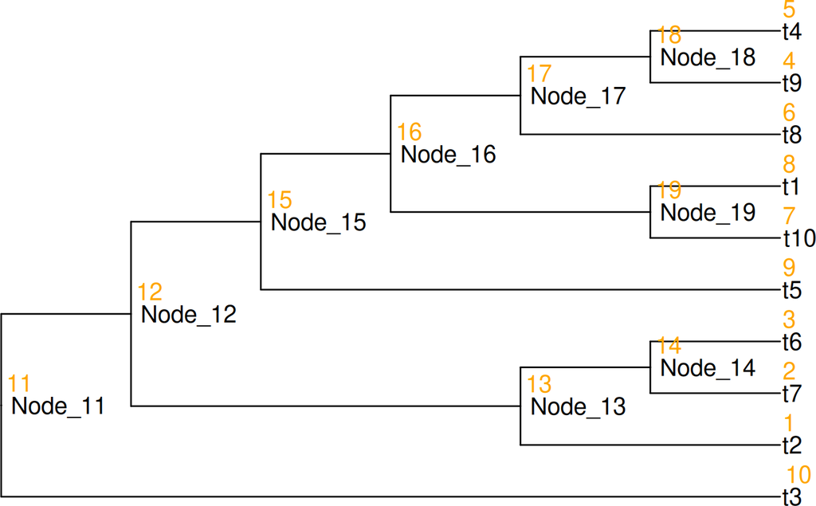

Figure 5: An example tree with node labels and numbers in black and orange texts, respectively

```r
data("tinyTree")
ggtree(tinyTree, branch.length = "none") +
    geom_text2(aes(label = label), hjust = -0.1, size = 5.5) +
    geom_text2(aes(label = node), vjust = -0.8,
               hjust = -0.2, color = 'orange', size = 5.5)
```

### 2.8.1 Conversion of the node label and the node number

The translation between the node labels and node numbers can be achieved by the function `convertNode`.

```r
convertNode(tree = tinyTree, node = c(12, 1, 4))
```

```
## [1] "Node_12" "t2"      "t9"
```

```r
convertNode(tree = tinyTree, node = c("t4", "Node_18"))
```

```
##      t4 Node_18
##       5      18
```

### 2.8.2 Find the descendants

To get descendants that are at the leaf level, we could set the argument `only.leaf = TRUE` for the function `findDescendant`.

```r
# only the leaf nodes
findDescendant(tree = tinyTree, node = 17, only.leaf = TRUE)
```

```
## $Node_17
## [1] 4 5 6
```

When `only.leaf = FALSE`, all descendants are returned.

```r
# all descendant nodes
findDescendant(tree = tinyTree, node = 17, only.leaf = FALSE)
```

```
## $Node_17
## [1]  4  5  6 18
```

### 2.8.3 More functions

We list some functions that might also be useful in Table 1. More are available in the package, and we encourage users to contribute their functions that might be helpful for others.

Table 1: A table lists some functions operating on the `phylo` object that are available in the `TreeSummarizedExperiment`.

| Functions | Goal |
| --- | --- |
| printNode | print out the information of nodes |
| countNode | count the number of nodes |
| distNode | give the distance between a pair of nodes |
| matTree | list paths of a tree |
| findAncestor | find ancestor nodes |
| findChild | find child nodes |
| findSibling | find sibling nodes |
| shareNode | find the first node shared in the paths of nodes to the root |
| unionLeaf | find the union of descendant leaves |
| trackNode | track nodes by adding alias labels to a phylo object |
| isLeaf | test whether a node is a leaf node |

## 2.9 Custom functions for the `TreeSummarizedExperiment` class

```r
# tse: a TreeSummarizedExperiment object
# rowLeaf: specific leaves
subsetByLeaf <- function(tse, rowLeaf) {
  # if rowLeaf is provided as node labels, convert them to node numbers
  if (is.character(rowLeaf)) {
    rowLeaf <- convertNode(tree = rowTree(tse), node = rowLeaf)
  }

  # subset data by leaves
  sse <- subsetByNode(tse, rowNode = rowLeaf)

  # update the row tree
    ## -------------- new tree: drop leaves ----------
    oldTree <- rowTree(sse)
    newTree <- ape::keep.tip(phy = oldTree, tip = rowLeaf)

    ## -------------- update the row link ----------
    # track the tree
    track <- trackNode(oldTree)
    track <- ape::keep.tip(phy = track, tip = rowLeaf)

    # row links
    rowL <- rowLinks(sse)
    rowL <- DataFrame(rowL)

    # update the row links:
    #   1. use the alias label to track and updates the nodeNum
    #   2. the nodeLab should be updated based on the new tree using the new
    #      nodeNum
    #   3. lastly, update the nodeLab_alias
    rowL$nodeNum <- convertNode(tree = track, node = rowL$nodeLab_alias,
                              message = FALSE)
    rowL$nodeLab <- convertNode(tree = newTree, node = rowL$nodeNum,
                              use.alias = FALSE, message = FALSE)
    rowL$nodeLab_alias <- convertNode(tree = newTree, node = rowL$nodeNum,
                                    use.alias = TRUE, message = FALSE)
    rowL$isLeaf <- isLeaf(tree = newTree, node = rowL$nodeNum)

    rowNL <- new("LinkDataFrame", rowL)

    ## update the row tree and links
    BiocGenerics:::replaceSlots(sse,
                              rowLinks = rowNL,
                              rowTree = list(phylo = newTree))
}
```

The row tree is updated after the subsetting. It now has only two leaves, `t2` and `t3`.

```r
(both_sse <- subsetByLeaf(tse = both_tse, rowLeaf = c("t2", "t3")))
```

```
## class: TreeSummarizedExperiment
## dim: 3 4
## metadata(0):
## assays(1): Count
## rownames(3): entity1 entity2 entity3
## rowData names(4): Kingdom Phylum Class OTU
## colnames(4): sample1 sample2 sample3 sample4
## colData names(2): gg group
## reducedDimNames(0):
## mainExpName: NULL
## altExpNames(0):
## rowLinks: a LinkDataFrame (3 rows)
## rowTree: 1 phylo tree(s) (2 leaves)
## colLinks: a LinkDataFrame (4 rows)
## colTree: 1 phylo tree(s) (4 leaves)
## referenceSeq: a DNAStringSet (3 sequences)
```

```r
rowLinks(both_sse)
```

```
## LinkDataFrame with 3 rows and 5 columns
##             nodeLab nodeLab_alias   nodeNum    isLeaf   whichTree
##         <character>   <character> <integer> <logical> <character>
## entity1          t3       alias_1         1      TRUE       phylo
## entity2          t3       alias_1         1      TRUE       phylo
## entity3          t2       alias_2         2      TRUE       phylo
```

# Reference

Lun, Aaron, and Davide Risso. 2020. “SingleCellExperiment: S4 Classes for Single Cell Data.”

Paradis, E, and K Schliep. 2019. “ape 5.0: an environment for modern phylogenetics and evolutionary analyses in R.” *Bioinformatics* 35: 526–28.

Wang, Li-Gen, Tommy Tsan-Yuk Lam, Shuangbin Xu, Zehan Dai, Lang Zhou, Tingze Feng, Pingfan Guo, et al. 2019. “Treeio: An R Package for Phylogenetic Tree Input and Output with Richly Annotated and Associated Data.” *Molecular Biology and Evolution* 37 (2): 599–603. https://doi.org/10.1093/molbev/msz240.

Yu, Guangchuang. 2020. *tidytree: A Tidy Tool for Phylogenetic Tree Data Manipulation*.

Yu, Guangchuang, David K. Smith, Huachen Zhu, Yi Guan, and Tommy Tsan Yuk Lam. 2017. “Ggtree: An R Package for Visualization and Annotation of Phylogenetic Trees with Their Covariates and Other Associated Data.” *Methods in Ecology and Evolution* 8 (1): 28–36.